# Overfitting

# Exercises Part 2

## Questions

The following exercises are inspired by Chapter 5.3.1 of ISLR.

```r
# Load packages
# NOTE: You might first need to install the ISLR package
library(tidyverse)
library(tidymodels)
library(ISLR) # install the package ISLR if you haven't already

# Load data
data(Auto)

# Select three variables from Auto data
# Save as a data frame called "cars"
cars <- Auto %>%
  dplyr::select(mpg, horsepower, year)
head(cars)
##   mpg horsepower year
## 1  18        130   70
## 2  15        165   70
## 3  18        150   70
## 4  16        150   70
## 5  17        140   70
## 6  15        198   70
dim(cars)
## [1] 392   3
```

Let’s use the `cars` data to compare three **linear regression models** of fuel efficiency in miles per gallon (`mpg`) by engine power (`horsepower`):

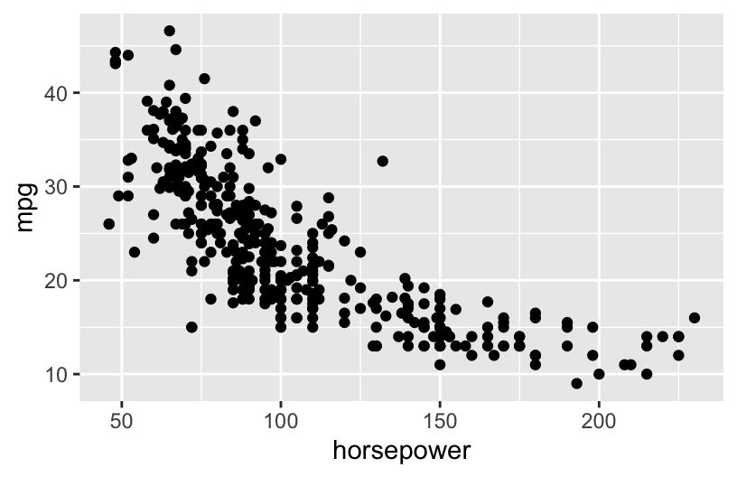

```r
# Raw data
cars_plot <- ggplot(cars, aes(x = horsepower, y = mpg)) +
  geom_point()
cars_plot
```

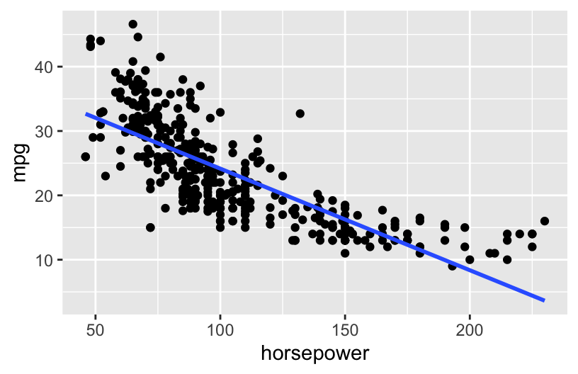

```r
# model 1: 1 predictor (y = b0 + b1 x)
cars_plot +
  geom_smooth(method = "lm", se = FALSE)
```

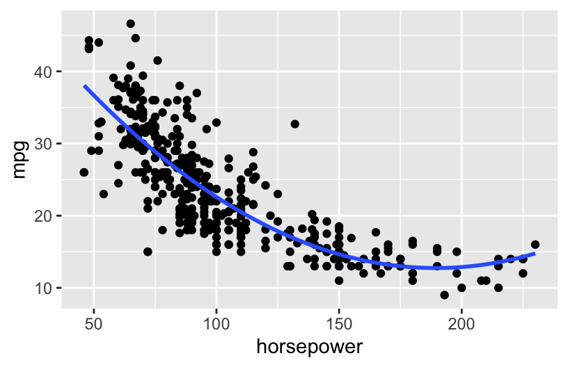

```r
# model 2: 2 predictors (y = b0 + b1 x + b2 x^2)
cars_plot +
  geom_smooth(method = "lm", se = FALSE, formula = y ~ poly(x, 2))
```

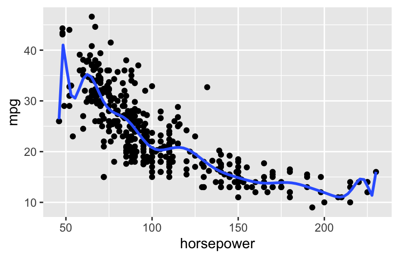

```r
# model 3: 19 predictors (y = b0 + b1 x + b2 x^2 + ... + b19 x^19)
cars_plot +
  geom_smooth(method = "lm", se = FALSE, formula = y ~ poly(x, 19))
```

**Goal**

Let’s evaluate and compare these models by **training** and **testing** them using different data.

1. **155 review: set.seed()**

Run the two chunks below *multiple* times each. Afterward, summarize what `set.seed()` does and why it’s important to being able to *reproduce* a random sample.

```r
sample_n(cars, 2)
##     mpg horsepower year
## 128  19        100   74
## 373  27         90   82
```

```r
set.seed(253)
sample_n(cars, 2)
##      mpg horsepower year
## 224 15.5        145   77
## 61  20.0         90   72
```

2. **Training and test sets**

Let’s *randomly* split our original 392 sample cars into two separate pieces: select 80% of the cars to **train (build)** the model and the other 20% to **test (evaluate)** the model.

```r
# Set the random number seed
set.seed(8)

# Split the cars data into 80% / 20%
# Ensure that the sub-samples are similar with respect to mpg
cars_split <- initial_split(cars, strata = mpg, prop = 0.8)
```

```r
# Check it out
# What do these numbers mean?
cars_split
## <Training/Testing/Total>
## <312/80/392>
```

```r
# Get the training data from the split
cars_train <- cars_split %>%
  training()

# Get the testing data from the split
cars_test <- cars_split %>%
  testing()
```

```r
# The original data has 392 cars
nrow(cars)
## [1] 392

# How many cars are in cars_train?
nrow(cars_train)
## [1] 312

# How many cars are in cars_test?
nrow(cars_test)
## [1] 80
```

3. **Reflect on the above code**
1. Why do we want the training and testing data to be similar with respect to `mpg` (`strata = mpg`)? What if they *weren’t*?

> Suppose, for example, the training cars all had higher mpg than the test cars. Then the training model likely would not perform well on the test cars, thus we’d get an overly pessimistic measure of model quality.
2. Why did we need all this new code instead of just using the *first* 80% of cars in the sample for training and the *last* 20% for testing?

> If the cars are ordered in some way (eg: from biggest to smallest) then our training and testing samples would have systematically different properties.
4. **Build the training model**

```r
# STEP 1: model specification
lm_spec <- linear_reg() %>%
  set_mode("regression") %>%
  set_engine("lm")

# STEP 2: model estimation using the training data
# Construct the 19th order polynomial model using the TRAINING data
model_19_train <- ___ %>%
  ___(mpg ~ poly(horsepower, 19), data = ___)
```

```r
# STEP 1: model specification
lm_spec <- linear_reg() %>%
  set_mode("regression") %>%
  set_engine("lm")

# STEP 2: model estimation using the training data
# Construct the 19th order polynomial model using the TRAINING data
model_19_train <- lm_spec %>%
  fit(mpg ~ poly(horsepower, 19), data = cars_train)
```

5. **Evaluate the training model**

```r
# How well does the TRAINING model predict the TRAINING data?
# Calculate the training (in-sample) MAE
model_19_train %>%
  augment(new_data = ___) %>%
  mae(truth = mpg, estimate = .pred)
```

```r
# How well does the training model predict the training data?
# Calculate the training (in-sample) MAE
model_19_train %>%
  augment(new_data = cars_train) %>%
  mae(truth = mpg, estimate = .pred)
## # A tibble: 1 × 3
##   .metric .estimator .estimate
##   <chr>   <chr>          <dbl>
## 1 mae     standard        2.99
```

```r
# How well does the TRAINING model predict the TEST data?
# Calculate the test MAE
model_19_train %>%
  augment(new_data = ___) %>%
  mae(truth = mpg, estimate = .pred)
```

```r
# Calculate the test MAE
model_19_train %>%
  augment(new_data = cars_test) %>%
  mae(truth = mpg, estimate = .pred)
## # A tibble: 1 × 3
##   .metric .estimator .estimate
##   <chr>   <chr>          <dbl>
## 1 mae     standard        6.59
```

6. **Punchline**

The table below summarizes your results for `train_model_19` as well as the other two models of interest. (You should confirm the other two model results outside of class!)

| Model | Training MAE | Testing MAE |
| --- | --- | --- |
| `mpg ~ horsepower` | 3.78 | 4.00 |
| `mpg ~ poly(horsepower, 2)` | 3.20 | 3.49 |
| `mpg ~ poly(horsepower, 19)` | 2.99 | 6.59 |

Let us discuss following and reflect on why each answer *makes sense*:

1. *Within* each model, how do the training errors compare to the testing errors? (This isn’t *always* the case, but is common.)

> the training errors are smaller
2. What about the training and test errors for the third model suggest that it is *overfit* to our sample data?

> the test MAE is much larger than the training MAE
3. Which model seems the best with respect to the *training* errors?

> the 19th order polynomial
4. Which model is the best with respect to the *testing* errors?

> the quadratic
5. Which model would you choose?

> the quadratic
7. **Final reflection**
1. The training / testing procedure provided a more honest evaluation and comparison of our model predictions. How might we *improve* upon this procedure? What problems can you anticipate in splitting our data into 80% / 20%?
2. Summarize the key themes from today in your own words.
8. **STAT 155 REVIEW: data drill**
1. Construct and interpret a plot of `mpg` vs `horsepower` and `year`.
2. Calculate the average `mpg`.
3. Calculate the average `mpg` for each `year`. HINT: `group_by()`
4. Plot the *average* `mpg` by `year`.
9. **Code for the curious (optional)**

I wrote a function calculate_MAE() to automate the calculations in the table. If you’re curious, pick through this code!

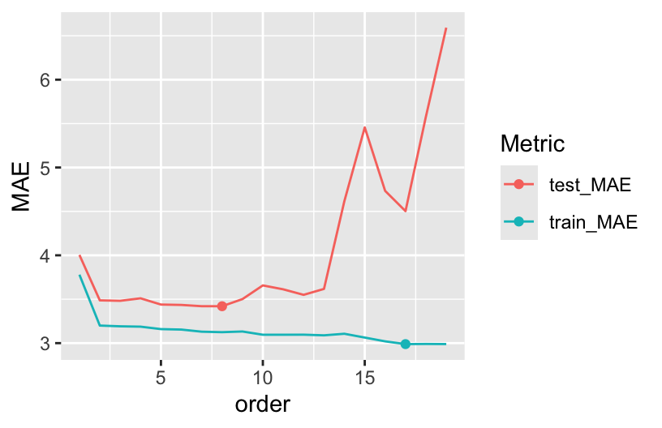

```r
# Write function to calculate MAEs
calculate_MAE <- function(poly_order){
  # Construct a training model
  model <- lm_spec %>%
    fit(mpg ~ poly(horsepower, poly_order), cars_train)

  # Calculate the training MAE
  train_it <- model %>%
    augment(new_data = cars_train) %>%
    mae(truth = mpg, estimate = .pred)

  # Calculate the testing MAE
  test_it <- model %>%
    augment(new_data = cars_test) %>%
    mae(truth = mpg, estimate = .pred)

  # Return the results
  return(data.frame(train_MAE = train_it$.estimate, test_MAE = test_it$.estimate))
}

# Calculate training and testing MSEs
calculate_MAE(poly_order = 1)
##   train_MAE test_MAE
## 1  3.779331 4.004333
calculate_MAE(poly_order = 2)
##   train_MAE test_MAE
## 1  3.199882 3.487022
calculate_MAE(poly_order = 19)
##   train_MAE test_MAE
## 1  2.989305 6.592341

# For those of you interested in trying all orders...

results <- purrr::map_df(1:19,calculate_MAE) %>%
  mutate(order = 1:19) %>%
  pivot_longer(cols=1:2,names_to='Metric',values_to = 'MAE')

results %>%
  ggplot(aes(x = order, y = MAE, color = Metric)) +
  geom_line() +
  geom_point(data = results %>% filter(Metric == 'test_MAE') %>% slice_min(MAE)) +
  geom_point(data = results %>% filter(Metric == 'train_MAE') %>% slice_min(MAE))
```

# Solutions

## Small Group Discussion

**Data**

**Solution**

Each group will have slightly different plots because they have different samples of data.

Throughout the solutions I’ll use one of the datasets as an example:

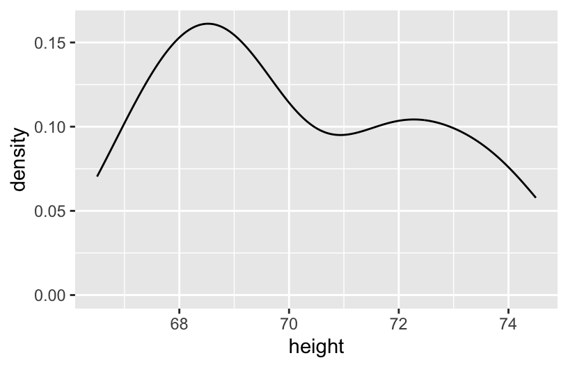

```r
humans <- read.csv("https://Mac-Stat.github.io/data/bodyfat50.csv") %>%
  filter(ankle < 30) %>%
  rename(body_fat = fatSiri)

ggplot(humans, aes(x = height)) +
  geom_density()
```

**Model building**

**Solution**

Each group will have slightly different coefficients because they have different samples of data.

```r
# STEP 1: model specification
lm_spec <- linear_reg() %>%
  set_mode('regression') %>%
  set_engine('lm')

# STEP 2: model estimation
model_1 <- lm_spec %>%
  fit(height ~ hip, data = humans)

# Check out the coefficients
model_1  %>%
  tidy()
## # A tibble: 2 × 5
##   term        estimate std.error statistic      p.value
##   <chr>          <dbl>     <dbl>     <dbl>        <dbl>
## 1 (Intercept)   52.5      7.68        6.84 0.0000000460
## 2 hip            0.179    0.0778      2.30 0.0272
```

**Model evaluation**

**Solution**

Again, each group will have slightly different answers here because they have different samples of data.

```r
# Calculate the R^2 for model_1
model_1 %>%
  glance()
## # A tibble: 1 × 12
##   r.squared adj.r.squared sigma statistic p.value    df logLik   AIC   BIC
##       <dbl>         <dbl> <dbl>     <dbl>   <dbl> <dbl>  <dbl> <dbl> <dbl>
## 1     0.125         0.101  2.26      5.29  0.0272     1  -86.1  178.  183.
## # ℹ 3 more variables: deviance <dbl>, df.residual <int>, nobs <int>

# Use your model to predict height for your subjects
# Just print the first 6 results
model_1 %>%
  augment(new_data = humans) %>%
  head()
## # A tibble: 6 × 21
##   .pred .resid fatBrozek body_fat density   age weight height adiposity
##   <dbl>  <dbl>     <dbl>    <dbl>   <dbl> <int>  <dbl>  <dbl>     <dbl>
## 1  70.3  -1.09      24.7     25.4    1.04    43   177    69.2      26
## 2  70.8  -1.52      22       22.5    1.05    38   187.   69.2      27.5
## 3  70.2  -1.19       9.4      8.8    1.08    29   161.   69        23.8
## 4  68.9   4.58       7.1      6.3    1.08    49   153.   73.5      19.9
## 5  69.3   2.91       9.9      9.4    1.08    23   160.   72.2      21.6
## 6  70.2  -2.48      22.7     23.3    1.05    52   167    67.8      25.6
## # ℹ 12 more variables: fatFreeWeight <dbl>, neck <dbl>, chest <dbl>,
## #   abdomen <dbl>, hip <dbl>, thigh <dbl>, knee <dbl>, ankle <dbl>,
## #   biceps <dbl>, forearm <dbl>, wrist <dbl>, hipin <dbl>

# Calculate the MAE, i.e. typical prediction error, for your model
model_1 %>%
  augment(new_data = humans) %>%
  mae(truth = height, estimate = .pred)
## # A tibble: 1 × 3
##   .metric .estimator .estimate
##   <chr>   <chr>          <dbl>
## 1 mae     standard        1.88
```

**Reflection**

**Solution**

$R^2$ would increase and MAE would decrease.

**BONUS**

**Solution**

Review your notes from last class and stop by office hours to discuss!

## Exercises (Part 1)

1. **Select a model**

**Solution**

Will vary by group. MAE is calculated here for each model.

*REMINDER: Throughout the solutions I’m using one of the datasets as an example: `bodyfat50.csv`.*

```r
# Build the models
model_1 <- lm_spec %>%
  fit(height ~ hip, data = humans)
model_2 <- lm_spec %>%
  fit(height ~ hip + weight, data = humans)
model_3 <- lm_spec %>%
  fit(height ~ chest * age * weight * body_fat * abdomen + hip + thigh + knee + ankle + biceps + forearm + wrist, data = humans)

# Evaluate the models
model_1 %>%
  augment(new_data = humans) %>%
  mae(truth = height, estimate = .pred)
## # A tibble: 1 × 3
##   .metric .estimator .estimate
##   <chr>   <chr>          <dbl>
## 1 mae     standard        1.88
model_2 %>%
  augment(new_data = humans) %>%
  mae(truth = height, estimate = .pred)
## # A tibble: 1 × 3
##   .metric .estimator .estimate
##   <chr>   <chr>          <dbl>
## 1 mae     standard        1.67
model_3 %>%
  augment(new_data = humans) %>%
  mae(truth = height, estimate = .pred)
## # A tibble: 1 × 3
##   .metric .estimator .estimate
##   <chr>   <chr>          <dbl>
## 1 mae     standard    1.53e-10
```

2. **Share your results.**

**Solution**

Done! (Model 3 had the best MAE for this dataset.)

3. **Intuition.**

**Solution**

Answers will vary.

4. **How well does your model do in the real world?**

**Solution**

```r
# Predict height (assume, for example, I choose model_1)
model_1 %>%
  augment(new_data = new_patients) %>%
  head()
## # A tibble: 6 × 21
##   .pred .resid fatBrozek body_fat density   age weight height adiposity
##   <dbl>  <dbl>     <dbl>    <dbl>   <dbl> <int>  <dbl>  <dbl>     <dbl>
## 1  71.5 -1.96       27.1     28      1.04    62   201.   69.5      29.3
## 2  70.4 -0.141      20.9     21.3    1.05    42   163    70.2      23.3
## 3  69.7 -0.497      26.1     27      1.04    72   168    69.2      24.7
## 4  69.1 -1.39        4.1      3      1.09    35   152.   67.8      23.4
## 5  68.5 -2.99        1.9      0.7    1.1     35   126.   65.5      20.6
## 6  71.9 -1.91       31       32.3    1.03    57   206.   70        29.5
## # ℹ 12 more variables: fatFreeWeight <dbl>, neck <dbl>, chest <dbl>,
## #   abdomen <dbl>, hip <dbl>, thigh <dbl>, knee <dbl>, ankle <dbl>,
## #   biceps <dbl>, forearm <dbl>, wrist <dbl>, hipin <dbl>
```

```r
# Calculate the MAE for model_1
model_1 %>%
  augment(new_data = new_patients) %>%
  mae(truth = height, estimate = .pred)
## # A tibble: 1 × 3
##   .metric .estimator .estimate
##   <chr>   <chr>          <dbl>
## 1 mae     standard        1.73

# Calculate the MAE for model_2
model_2 %>%
  augment(new_data = new_patients) %>%
  mae(truth = height, estimate = .pred)
## # A tibble: 1 × 3
##   .metric .estimator .estimate
##   <chr>   <chr>          <dbl>
## 1 mae     standard        1.68

# Calculate the MAE for model_3
model_3 %>%
  augment(new_data = new_patients) %>%
  mae(truth = height, estimate = .pred)
## # A tibble: 1 × 3
##   .metric .estimator .estimate
##   <chr>   <chr>          <dbl>
## 1 mae     standard        105.
```

5. **Reflection**

**Solution**

A few takeaways:

- In general, models tend to perform worse on new data than on the data on which they were built/trained.
- In this particular dataset, Model 2 looks best on new data, and Model 3 performs horribly.
- Model 3 is *overfit* to the training data. This is more likely to happen with an overly complicated model.

## Exercises (Part 2)

1. **155 review: set.seed()**

**Solution**

`set.seed()` is used to create the same “random numbers” each time a random function is called.

Note that is if you want to get exactly the same random result, `set.seed()` needs to be run right before the call to random function, every time.

It is important so that you can reproduce the same random sample every time you knit your work.

There might be different results across computers/platforms as they might be using different pseudo-random number generators. The most important thing is for your code to be consistent.

2. **Training and test sets**

**Solution**

```r
# Set the random number seed
set.seed(8)

# Split the cars data into 80% / 20%
# Ensure that the sub-samples are similar with respect to mpg
cars_split <- initial_split(cars, strata = mpg, prop = 0.8)

# Check it out
cars_split
## <Training/Testing/Total>
## <312/80/392>

# Get the training data from the split
cars_train <- cars_split %>%
  training()

# Get the testing data from the split
cars_test <- cars_split %>%
  testing()

# The original data has 392 cars
nrow(cars)
## [1] 392

# How many cars are in cars_train?
nrow(cars_train)
## [1] 312

# How many cars are in cars_test?
nrow(cars_test)
## [1] 80
```

3. **Reflect on the above code**

**Solution**

1. Suppose, for example, the training cars all had higher `mpg` than the test cars. Then the training model likely would not perform well on the test cars, thus we’d get an overly pessimistic measure of model quality.
2. If the cars are ordered in some way (eg: from biggest to smallest) then our training and testing samples would have systematically different properties.
4. **Build the training model**

**Solution**

```r
# STEP 1: model specification
lm_spec <- linear_reg() %>%
  set_mode("regression") %>%
  set_engine("lm")

# STEP 2: model estimation using the training data
# Construct the 19th order polynomial model using the TRAINING data
model_19_train <- lm_spec %>%
  fit(mpg ~ poly(horsepower, 19), data = cars_train)
```

5. **Evaluate the training model**

**Solution**

```r
# How well does the training model predict the training data?
# Calculate the training (in-sample) MAE
model_19_train %>%
  augment(new_data = cars_train) %>%
  mae(truth = mpg, estimate = .pred)
## # A tibble: 1 × 3
##   .metric .estimator .estimate
##   <chr>   <chr>          <dbl>
## 1 mae     standard        2.99

# How well does the training model predict the test data?
# Calculate the test MAE
model_19_train %>%
  augment(new_data = cars_test) %>%
  mae(truth = mpg, estimate = .pred)
## # A tibble: 1 × 3
##   .metric .estimator .estimate
##   <chr>   <chr>          <dbl>
## 1 mae     standard        6.59
```

6. **Punchline**

**Solution**

1. the training errors are smaller
2. the test MAE is much larger than the training MAE
3. the 19th order polynomial
4. the quadratic
5. the quadratic

**Code for the curious**

I wrote a function `calculate_MAE()` to automate the calculations in the table. If you’re curious, pick through this code!

```r
# Write function to calculate MAEs
calculate_MAE <- function(poly_order){
  # Construct a training model
  model <- lm_spec %>%
    fit(mpg ~ poly(horsepower, poly_order), cars_train)

  # Calculate the training MAE
  train_it <- model %>%
    augment(new_data = cars_train) %>%
    mae(truth = mpg, estimate = .pred)

  # Calculate the testing MAE
  test_it <- model %>%
    augment(new_data = cars_test) %>%
    mae(truth = mpg, estimate = .pred)

  # Return the results
  return(data.frame(train_MAE = train_it$.estimate, test_MAE = test_it$.estimate))
}

# Calculate training and testing MSEs
calculate_MAE(poly_order = 1)
##   train_MAE test_MAE
## 1  3.779331 4.004333
calculate_MAE(poly_order = 2)
##   train_MAE test_MAE
## 1  3.199882 3.487022
calculate_MAE(poly_order = 19)
##   train_MAE test_MAE
## 1  2.989305 6.592341
```

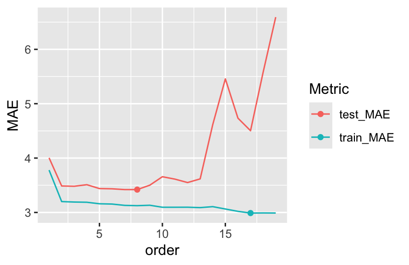

```r
# For those of you interested in trying all orders...

results <- purrr::map_df(1:19,calculate_MAE) %>%
  mutate(order = 1:19) %>%
  pivot_longer(cols=1:2,names_to='Metric',values_to = 'MAE')

results %>%
  ggplot(aes(x = order, y = MAE, color = Metric)) +
  geom_line() +
  geom_point(data = results %>% filter(Metric == 'test_MAE') %>% slice_min(MAE)) +
  geom_point(data = results %>% filter(Metric == 'train_MAE') %>% slice_min(MAE))
```

7. **Final reflection**

**Solution**

This will be discussed in the next video!

8. **STAT 155 REVIEW: data drill**

**Solution**

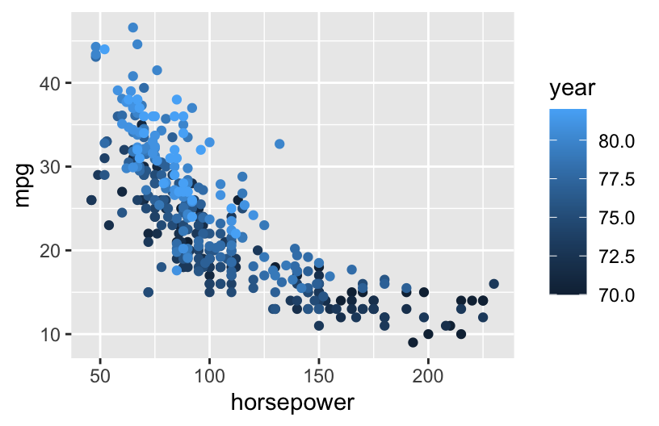

```r
# a. One of many options
ggplot(cars, aes(x = horsepower, y = mpg, color = year)) +
  geom_point()
```

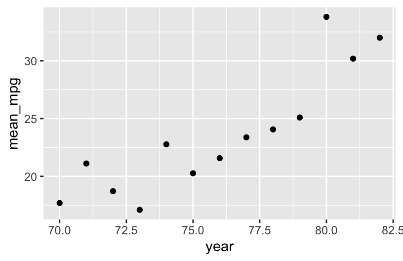

```r
# b
cars %>%
  summarize(mean(mpg))
##   mean(mpg)
## 1  23.44592

# c
cars %>%
  group_by(year) %>%
  summarize(mean_mpg = mean(mpg))
## # A tibble: 13 × 2
##     year mean_mpg
##    <dbl>    <dbl>
##  1    70     17.7
##  2    71     21.1
##  3    72     18.7
##  4    73     17.1
##  5    74     22.8
##  6    75     20.3
##  7    76     21.6
##  8    77     23.4
##  9    78     24.1
## 10    79     25.1
## 11    80     33.8
## 12    81     30.2
## 13    82     32

# d
cars %>%
  group_by(year) %>%
  summarize(mean_mpg = mean(mpg)) %>%
  ggplot(aes(y = mean_mpg, x = year)) +
  geom_point()
```

# Wrapping Up

*If you didn’t finish the exercises during class time today, no problem!* Just be sure to complete them outside of class, review the solutions in the online manual, and ask any outstanding questions on course Moodle or in office hours.